# Classificação de Exoplanetas

## Trabalho Prático 1 - Aprendizado de Máquina

Aluna: Maria Luísa Costa Pinto

Matrícula: 2018664772

Neste trabalho são praticados conceitos aprendidos em Aprendizado de Máquina como o uso de alguns dos principais métodos de classificação, a avaliação de modelos e a interpretação e apresentação de resultados de experimentos.

Dentro deste objetivo, o desafio proposto é utilizar e comparar métodos de classificação baseados em princípios diferentes para resolver um problema de classificação binária de candidatos a exoplanetas.

Neste notebook estão contidas todas as etapas deste experimento, descrição dos dados, dos desafios e das decisões de modelagem e implementação.

```python
#
#  Importação das bibliotecas necessárias para execução do experimento
#

import numpy as np
import pandas as pd

import matplotlib as mpl
import matplotlib.pyplot as plt

from IPython.display import display

from sklearn import svm
from sklearn import metrics
from sklearn import ensemble
from sklearn import neighbors
from sklearn import feature_selection
from sklearn import naive_bayes
from sklearn.naive_bayes import GaussianNB, BernoulliNB, MultinomialNB
from sklearn.tree import DecisionTreeClassifier
from sklearn.model_selection import train_test_split
from sklearn import metrics
from sklearn.ensemble import GradientBoostingClassifier
from sklearn.model_selection import KFold
from sklearn.model_selection import StratifiedKFold
from sklearn.metrics import roc_curve, auc, brier_score_loss, precision_score, recall_score, f1_score

from scipy import interp
```

# Preparação e leitura dos dados

Neste trabalho estamos interessados em resolver um problema de classificação binária de candidatos a exoplanetas encontrados pela sonda espacial Kepler da NASA. Um exoplaneta é um planeta fora do sistema solar (i.e. que não orbita o sol). A sonda primeiro identifica sinais de possíveis exoplanetas, chamados de Kepler Object of Interest (KOI). Porém nem todos os KOIs são de fato exoplanetas, alguns se tratam de falsos positivos de origens diversas. A tarefa é então classificar os KOIs entre exoplanetas confirmados e falsos positivos. Cada linha do arquivo corresponde a um KOI e as features são características estimadas de cada (possível) exoplaneta (tamanho, temperatura, features da estrela hospedeira, etc).

Dados retirados do [NASA Exoplanet Archive](https://exoplanetarchive.ipac.caltech.edu/).

```python
#
# Constantes utilizadas no experimento
#

# Arquivo de entrada
INPUT_FILEPATH = "koi_data.csv"

# Variavel que queremos predizer
TARGET = "koi_disposition"

# Tamanho do conjunto de validacao (proporcao)
VAL_SIZE = 0.3

# Numero de features a serem usadas
N_FEATURES = 41
```

```python
#
# Leitura do Dataset (DataFrame do Pandas)
#

df = pd.read_csv(INPUT_FILEPATH, error_bad_lines=False, sep=',')

# Informacoes basicas sobre os dados
print("Numero de linhas: {}".format(df.shape[0]))
print("Numero de colunas: {}".format(df.shape[1]))
print("Dados faltando: {}".format(df.isnull().sum().sum()))

print("\nAmostra:")
with pd.option_context("max_columns", 12):
    display(df.head(20))

# Exibe uma lista com as features
features = list(df.columns)
features.remove(TARGET)

print("Target: {}".format(TARGET))
print("Features:")
print("\n".join(["  " + x for x in features]))

mpl.rc('font', size=14)
```

```
Numero de linhas: 5202
Numero de colunas: 43
Dados faltando: 0

Amostra:
```

|  | kepoi_name | koi_disposition | koi_period | koi_impact | koi_duration | koi_depth | ... | koi_dicco_mra | koi_dicco_mdec | koi_dicco_msky | koi_dikco_mra | koi_dikco_mdec | koi_dikco_msky |
| --- | --- | --- | --- | --- | --- | --- | --- | --- | --- | --- | --- | --- | --- |
| 0 | K00752.01 | CONFIRMED | 9.48804 | 0.146 | 2.95750 | 615.8 | ... | -0.010 | 0.200 | 0.200 | 0.080 | 0.310 | 0.320 |
| 1 | K00752.02 | CONFIRMED | 54.41838 | 0.586 | 4.50700 | 874.8 | ... | 0.390 | 0.000 | 0.390 | 0.490 | 0.120 | 0.500 |
| 2 | K00754.01 | FALSE POSITIVE | 1.73695 | 1.276 | 2.40641 | 8079.2 | ... | -0.249 | 0.147 | 0.289 | -0.257 | 0.099 | 0.276 |
| 3 | K00755.01 | CONFIRMED | 2.52559 | 0.701 | 1.65450 | 603.3 | ... | 0.030 | -0.090 | 0.100 | 0.070 | 0.020 | 0.070 |
| 4 | K00114.01 | FALSE POSITIVE | 7.36179 | 1.169 | 5.02200 | 233.7 | ... | -4.506 | 7.710 | 8.930 | -4.537 | 7.713 | 8.948 |
| 5 | K00757.01 | CONFIRMED | 16.06865 | 0.052 | 3.53470 | 4914.3 | ... | 0.041 | -0.015 | 0.044 | 0.005 | 0.030 | 0.031 |
| 6 | K00001.01 | CONFIRMED | 2.47061 | 0.818 | 1.74319 | 14231.0 | ... | -0.009 | -0.300 | 0.300 | 0.015 | -0.270 | 0.270 |
| 7 | K00010.01 | CONFIRMED | 3.52250 | 0.631 | 3.19843 | 9145.7 | ... | 0.014 | -0.013 | 0.020 | -0.028 | 0.176 | 0.178 |
| 8 | K00112.02 | CONFIRMED | 3.70921 | 0.051 | 2.63020 | 131.1 | ... | 0.240 | -0.150 | 0.290 | 0.160 | -0.130 | 0.210 |
| 9 | K00742.01 | FALSE POSITIVE | 11.52145 | 2.483 | 3.63990 | 17984.0 | ... | 0.009 | -0.009 | 0.013 | 0.147 | 0.037 | 0.151 |
| 10 | K00743.01 | FALSE POSITIVE | 19.40394 | 0.804 | 12.21550 | 8918.7 | ... | -0.001 | 0.009 | 0.009 | -0.147 | -0.038 | 0.152 |
| 11 | K00744.01 | FALSE POSITIVE | 19.22139 | 1.065 | 4.79843 | 74284.0 | ... | 0.003 | 0.005 | 0.006 | -0.018 | -0.203 | 0.203 |
| 12 | K00745.01 | FALSE POSITIVE | 16.46984 | 0.292 | 9.43780 | 10479.0 | ... | -0.040 | -0.004 | 0.040 | 0.017 | 0.001 | 0.017 |
| 13 | K00746.01 | CONFIRMED | 9.27358 | 0.387 | 3.28750 | 1288.3 | ... | -0.059 | -0.008 | 0.059 | 0.042 | 0.344 | 0.346 |
| 14 | K00747.01 | CONFIRMED | 6.02930 | 0.258 | 1.58210 | 1912.7 | ... | 0.110 | 0.010 | 0.110 | -0.190 | -0.240 | 0.300 |
| 15 | K00748.01 | FALSE POSITIVE | 2.69637 | 0.044 | 3.61290 | 397.9 | ... | 1.080 | 2.190 | 2.440 | 0.890 | 2.320 | 2.490 |
| 16 | K00749.01 | CONFIRMED | 5.34955 | 0.092 | 3.02780 | 831.0 | ... | 0.040 | -0.020 | 0.040 | -0.020 | -0.030 | 0.040 |
| 17 | K00749.02 | CONFIRMED | 3.94105 | 0.226 | 2.59840 | 363.3 | ... | -0.230 | 0.350 | 0.420 | -0.240 | 0.340 | 0.420 |
| 18 | K00749.03 | CONFIRMED | 8.10905 | 0.025 | 3.59600 | 217.4 | ... | -0.110 | -0.140 | 0.180 | -0.150 | -0.150 | 0.220 |
| 19 | K00750.01 | CONFIRMED | 21.67699 | 0.896 | 3.45550 | 857.2 | ... | -0.100 | -0.040 | 0.110 | -0.280 | -0.230 | 0.360 |

20 rows × 43 columns

```
Target: koi_disposition
Features:
  kepoi_name
  koi_period
  koi_impact
  koi_duration
  koi_depth
  koi_ror
  koi_srho
  koi_prad
  koi_sma
  koi_incl
  koi_teq
  koi_insol
  koi_dor
  koi_max_sngle_ev
  koi_max_mult_ev
  koi_model_snr
  koi_steff
  koi_slogg
  koi_smet
  koi_srad
  koi_smass
  koi_kepmag
  koi_gmag
  koi_rmag
  koi_imag
  koi_zmag
  koi_jmag
  koi_hmag
  koi_kmag
  koi_fwm_stat_sig
  koi_fwm_sra
  koi_fwm_sdec
  koi_fwm_srao
  koi_fwm_sdeco
  koi_fwm_prao
  koi_fwm_pdeco
  koi_dicco_mra
  koi_dicco_mdec
  koi_dicco_msky
  koi_dikco_mra
  koi_dikco_mdec
  koi_dikco_msky
```

## Transformação

A feature que vamos prever foi convertida para binário (0, 1).

```python
df[TARGET] = (df[TARGET] == "CONFIRMED").astype(int)

print("Resultado:")

display(df[[TARGET]].sample(10))
```

```
Resultado:
```

|  | koi_disposition |
| --- | --- |
| 2271 | 0 |
| 1876 | 1 |
| 1531 | 1 |
| 3028 | 0 |
| 2612 | 1 |
| 2694 | 0 |
| 3943 | 0 |
| 577 | 0 |
| 1484 | 1 |
| 338 | 1 |

## Normalização dos dados

```python
#
# Cria a lista das features que serão usadas nos experimentos
#

# Foram removidas: a feature que estamos interessados em prever
#                  e a featute name, que consiste um um identificador textual de cada koi
features = list(df.columns)
features.remove(TARGET)
features.remove("kepoi_name")

# Calcula a media e subtrai dos dados
df[features] = df[features] - df[features].mean()

# Divide os dados pelo desvio padrão
df[features] = df[features] / df[features].std()

print("Resultado:")
df_mean = df[features].mean().round(2).to_frame("Media")
df_std = df[features].std().round(2).to_frame("Std")
with pd.option_context("max_rows", 15):
    display(df_mean.join(df_std))
```

```
Resultado:
```

|  | Media | Std |
| --- | --- | --- |
| koi_period | -0.0 | 1.0 |
| koi_impact | -0.0 | 1.0 |
| koi_duration | 0.0 | 1.0 |
| koi_depth | -0.0 | 1.0 |
| koi_ror | -0.0 | 1.0 |
| koi_srho | 0.0 | 1.0 |
| koi_prad | 0.0 | 1.0 |
| ... | ... | ... |
| koi_fwm_pdeco | 0.0 | 1.0 |
| koi_dicco_mra | 0.0 | 1.0 |
| koi_dicco_mdec | 0.0 | 1.0 |
| koi_dicco_msky | -0.0 | 1.0 |
| koi_dikco_mra | 0.0 | 1.0 |
| koi_dikco_mdec | 0.0 | 1.0 |
| koi_dikco_msky | -0.0 | 1.0 |

41 rows × 2 columns

## Seleção de features

Está sendo utilizado o Analysis of Variance (ANOVA) para selecionar features que serão utilizadas na etapa de classificação.

```python
#
# Cria um objeto skb que é usado posteriormente
#

skb = feature_selection.SelectKBest(feature_selection.f_classif, N_FEATURES)
skb = skb.fit(df[features], df[TARGET])
```

## Dados de treino e teste

```python
#
# Separa os dados em um conjunto para treino e outro para teste
#

idx = list(df.index)

np.random.shuffle(idx)

train_idx = idx[int(VAL_SIZE*len(idx)):]
test_idx = idx[:int(VAL_SIZE*len(idx))]

x_train = skb.transform(df.loc[train_idx, features])
x_test = skb.transform(df.loc[test_idx, features])
y_train = df.loc[train_idx, TARGET]
y_test = df.loc[test_idx, TARGET]

# Definição do x e y
x = skb.transform(df[features])
y = df[TARGET]
```

# Classificação

Na etapa de classificação foram testados seis métodos diferentes, que são: Naive Bayes, Decision Tree, k-Nearest Neighbors, Support Vector Machines, Random Forest e Gradient Tree Boosting. Para cada modelo foi calculada sua acurária e validação cruzada k-fold com k=5.

Além dissso foram realizadas variações nos hiperparâmetros dos métodos, a fim de chegar aos valores que obtiveram melhores resultados.

```python
#
# Variação da altura máxima da árvore em relação à acurácia
#   Esta funcao sera chamada para mostrar a variação dos parametros em relacao a acuracia
#   O parametro execs recebe via arrays, os valores do parametro variado e da acuracia
#   o parametro nameParam, recebe o nome do parâmetro
#

def showVariationsGraph(execs, nameParam):
    # define os arrays de valoes e acurácias
    values = []
    accs = []

    for e in execs:
        values.append(e[0])
        accs.append(e[2])

    print('O valor 0 da altura máxima indica que o parâmetro foi desconsiderado');

    # mostra o grafico
    y_pos = np.arange(len(values))

    plt.bar(y_pos, accs, align='center', alpha=0.5)
    plt.xticks(y_pos, values)
    plt.ylabel('Acurácia')
    plt.xlabel(nameParam)
    plt.title(nameParam + ' x Acurácia')
    plt.show()
```

## Naive Bayes

O Naive Bayes é um algoritmo probabilístico simples baseado no teorema de Bayes. Este utiliza dados de treino para formar um modelo probabilístico baseado na evidência das features nos dados. O algoritmo supõe que há uma independência entre as features do modelo. Isso significa que a presença de uma determinada feature não tem nenhuma relação com as outras.

```python
#
# Funcao que treina o modelo e mostra os resultados utilizando o Naive Bayes
# O Naive Bayes foi o método utilizado como baseline do experimento
#

def test_naive_bayes():
    # Instancializa o classificador
    clf = GaussianNB()

    # Treina o classificador
    clf = clf.fit(
        x_train,
        y_train
    )
    y_pred = clf.predict(x_test)
    train_acc = clf.score(x_train, y_train)
    test_acc = clf.score(x_test, y_test)

    print("Acuracia de treino: {:.3}".format(train_acc))
    print("Acuracia de validação: {:.3}".format(test_acc))
```

```python
test_naive_bayes()
```

```
Acuracia de treino: 0.923
Acuracia de validação: 0.916
```

## Decision Tree

Árvores de decisão são métodos de aprendizado de máquinas supervisionado não-paramétricos, muito utilizados em tarefas de classificação e regressão. Este método representa funções como árvores de decisão. Estas árvores são treinadas de acordo com um conjunto de treino (exemplos previamente classificados) e posteriormente, outros exemplos são classificados de acordo com essa mesma árvore.

```python
#
# Funcao que treina o modelo e mostra os resultados utilizando o Decision Tree
#

def test_decision_tree(max_depth):
    # Instancializa o classificador
    if(max_depth):
        clf = DecisionTreeClassifier(max_depth=max_depth)
    else:
        clf = DecisionTreeClassifier()

    # Treina o classificador
    clf = clf.fit(x_train, y_train)

    # Realiza predição
    y_pred = clf.predict(x_test)

    train_acc = clf.score(x_train, y_train)
    val_acc = clf.score(x_test, y_test)

    print("Acuracia do treino: {:.3}".format(train_acc))
    print("Acuracia do teste: {:.3}".format(val_acc))
    return [max_depth, train_acc, val_acc];
```

O parâmetro max_depth define a altura máxima da árvore. O método foi executado assumindo diferentes valores do parâmetro a fim de enconrar o melhor resultado.

```python
#
# Array que irá salvar as execuções com variações de parâmetros
#

execsDT = [];
```

```python
# primeiro teste, passando o parâmetro inválido
execsDT.append(test_decision_tree(0))
```

```
Acuracia do treino: 1.0
Acuracia do teste: 0.942
```

```python
execsDT.append(test_decision_tree(1))
```

```
Acuracia do treino: 0.731
Acuracia do teste: 0.733
```

```python
execsDT.append(test_decision_tree(10))
```

```
Acuracia do treino: 0.991
Acuracia do teste: 0.947
```

```python
execsDT.append(test_decision_tree(50))
```

```
Acuracia do treino: 1.0
Acuracia do teste: 0.942
```

```python
execsDT.append(test_decision_tree(100))
```

```
Acuracia do treino: 1.0
Acuracia do teste: 0.941
```

```
O valor 0 da altura máxima indica que o parâmetro foi desconsiderado
```

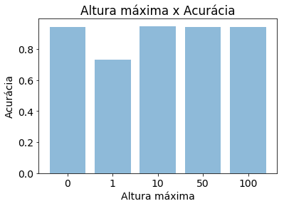

```python
#
# Mostra graficamente a variação de valores
#

showVariationsGraph(execsDT, 'Altura máxima')
```

## Support Vector Machine (SVM)

Uma máquina de vetores de suporte é um método de aprendizado supervisionado que analisa os dados e reconhece padrões, usado para classificação e análise de regressão. O SVM toma como entrada um conjunto de dados e prediz, para cada entrada dada, qual de duas possíveis classes a entrada faz parte, o que faz do SVM um classificador linear binário não probabilístico.

Um modelo SVM é uma representação de exemplos como pontos no espaço, mapeados de maneira que os exemplos de cada categoria sejam divididos por um espaço claro que seja tão amplo quanto possível. Os novos exemplos são então mapeados no mesmo espaço e preditos como pertencentes a uma categoria baseados em qual o lado do espaço eles são colocados.

```python
#
# Funcao que treina o modelo e mostra os resultados utilizando o SVM
#

def test_svm(c, kernel, gamma):
    clf = svm.SVC(C=c, kernel=kernel, gamma=gamma)

    clf = clf.fit(x_train, y_train)

    train_acc = clf.score(x_train, y_train)
    val_acc = clf.score(x_test, y_test)

    print("Acuracia do treino: {:.3}".format(train_acc))
    print("Acuracia do teste: {:.3}".format(val_acc))
```

O SVM recebe um parâmetro C, que é um parâmetro de otimização. Ele informa à otimização do SVM quanto se deseja evitar classificar erroneamente cada exemplo de treinamento. Para valores grandes de C, a otimização escolherá um hiperplano de margem menor se esse hiperplano fizer um trabalho melhor ao classificar todos os pontos de treinamento corretamente. O valor muito pequeno de C faz com que o otimizador procure por um hiperplano de separação de margem maior, mesmo se esse hiperplano classificar incorretamente mais pontos.

### Kernels

O SVM introduz a função kernel que transforma o espaço de dados original em um novo espaço com dimensões mais altas. Existem várias fórmulas para a função kernel, neste trabalho estamos trabalhando com o kernel linear, sigmoide, polinomial e radial.

#### Linear

É útil ao lidar com grandes vetores de dados esparsos. É frequentemente usado na categorização de texto. O kernel linear também funciona bem em problemas de regressão. A equação dada por:

$$ K(X,Y)=X^TY $$

```python
test_svm(0.01, "linear", "auto")
```

```
Acuracia do treino: 0.932
Acuracia do teste: 0.918
```

#### Sigmoid

Este kernel (no português sigmoide) pode ser usado como proxy para redes neurais. A equação é dada por:

$$ K(X,Y)=tanh(γ⋅X^TY+r) $$

```python
test_svm(0.01, "sigmoid", 2)
```

```
Acuracia do treino: 0.707
Acuracia do teste: 0.706
```

#### Polinomial

Este kernel induz o espaço de combinações polinomiais até certo ponto. Consequentemente, pode-se trabalhar com limites de decisão ligeiramente "dobrados", como parábolas com grau = 2. Em alguns casos combinações polinomiais não são flexíveis o suficiente para "dobrar" o espaço com força suficiente para capturar o ponto de interesse. Este kernel é popular no processamento de imagens. A equação é dada por:

$$ K(X,Y)=(γ⋅X^TY+r)d,γ>0 $$

```python
test_svm(0.01, "poly", "auto")
```

```
Acuracia do treino: 0.602
Acuracia do teste: 0.59
```

#### Radial basis function (RBF)

O tipo mais usado de função do kernel é o RBF. Porque tem resposta localizada e finita ao longo de todo o eixo x. É um kernel de propósito geral, usado quando não há conhecimento prévio sobre os dados. A equação é dada por:

$$ K(X,Y)=exp(∥X−Y∥^2/2σ^2) $$

```python
test_svm(0.01, "rbf", "auto")
```

```
Acuracia do treino: 0.901
Acuracia do teste: 0.88
```

O kernel linear obteve melhores resultados para este problema.

## k-Nearest Neighbors (KNN)

K-Nearest Neighbors é um dos muitos algoritmos de aprendizagem supervisionada usado no campo de data mining e machine learning, ele é um classificador onde o aprendizado é baseado no quão similar é um dado (um vetor) do outro. O treinamento é formado por vetores de n dimensões.

```python
#
# Funcao que treina o modelo e mostra os resultados utilizando o KNN
#

def test_knn(k):
    clf = neighbors.KNeighborsClassifier(n_neighbors=k)

    clf = clf.fit(x_train, y_train)

    train_acc = clf.score(x_train, y_train)
    val_acc = clf.score(x_test, y_test)

    print("K = {}".format(k))
    print("Acuracia do treino: {:.3}".format(train_acc))
    print("Acuracia do teste: {:.3}".format(val_acc))
    return [k, train_acc, val_acc];
```

O parâmetro k informa a quantidade de vizinhos. Na fase de classificação, k é uma constante definida pelo usuário e um vetor não rotulado é classificado atribuindo-se o rótulo que é mais frequente entre as k amostras de treinamento mais próximas a esse ponto de consulta.

```python
#
# Array que irá salvar as execuções com variações de parâmetros
#

execsKNN = [];
```

```python
execsKNN.append(test_knn(2))
```

```
K = 2
Acuracia do treino: 0.98
Acuracia do teste: 0.89
```

```python
execsKNN.append(test_knn(5))
```

```
K = 5
Acuracia do treino: 0.921
Acuracia do teste: 0.888
```

```python
execsKNN.append(test_knn(10))
```

```
K = 10
Acuracia do treino: 0.908
Acuracia do teste: 0.885
```

```python
execsKNN.append(test_knn(50))
```

```
K = 50
Acuracia do treino: 0.864
Acuracia do teste: 0.847
```

```
O valor 0 da altura máxima indica que o parâmetro foi desconsiderado
```

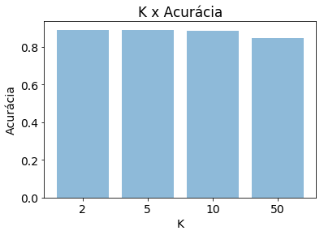

```python
#
# Variação da quantidade de vizinhos k em relação a acurácia
#

showVariationsGraph(execsKNN, 'K')
```

## Random Forest

Floresta Aleatória é um algoritmo de aprendizagem supervisionada que cria uma floresta de um modo aleatório. A floresta criada é uma combinação (ensemble) de árvores de decisão, em vários casos treinados com o método de bagging.

```python
#
# Funcao que treina o modelo e mostra os resultados utilizando o Random Forest
#

def test_random_forest(N):
    clf = ensemble.RandomForestClassifier(n_estimators=N)

    clf = clf.fit(x_train, y_train)

    train_acc = clf.score(x_train, y_train)
    val_acc = clf.score(x_test, y_test)

    print("N = {}".format(N))
    print("Acuracia do treino: {:.3}".format(train_acc))
    print("Acuracia do teste: {:.3}".format(val_acc))
    return [N, train_acc, val_acc];
```

O parâmetro N define a quantidade de árvores que serão criadas pelo Random Forest. O hiperparâmetro N que indica o número de árvores construídas pelo algoritmo antes de tomar uma votação ou fazer uma média de predições. Em geral, uma quantidade elevada de árvores aumenta a performance e torna as predições mais estáveis, mas também torna a computação mais lenta.

```python
#
# Array que irá salvar as execuções com variações de parâmetros
#

execsRF = [];
```

```python
execsRF.append(test_random_forest(5))
```

```
N = 5
Acuracia do treino: 0.996
Acuracia do teste: 0.953
```

```python
execsRF.append(test_random_forest(10))
```

```
N = 10
Acuracia do treino: 0.998
Acuracia do teste: 0.951
```

```python
execsRF.append(test_random_forest(50))
```

```
N = 50
Acuracia do treino: 1.0
Acuracia do teste: 0.969
```

```python
execsRF.append(test_random_forest(100))
```

```
N = 100
Acuracia do treino: 1.0
Acuracia do teste: 0.964
```

```
O valor 0 da altura máxima indica que o parâmetro foi desconsiderado
```

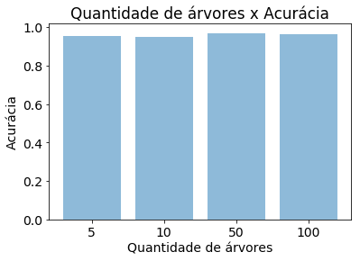

```python
#
# Mostra graficamente a variação de valores
#

showVariationsGraph(execsRF, 'Quantidade de árvores')
```

## Gradient Tree Boosting

Gradient Tree Boosting é uma técnica de aprendizado de máquina para problemas de regressão e classificação, que produz um modelo de previsão na forma de um conjunto de modelos de previsão fracos, a partir de árvores de decisão. Ele constrói o modelo em um modo de estágio, como outros métodos de otimização, e os generaliza ao permitir a otimização de uma função de perda arbitrariamente diferenciável.

```python
#
# Funcao que treina o modelo e mostra os resultados utilizando o Gradient Tree Boosting
#

def test_gradient_tree_boosting(N):
    clf = GradientBoostingClassifier(n_estimators=N)

    clf = clf.fit(x_train, y_train)

    train_acc = clf.score(x_train, y_train)
    val_acc = clf.score(x_test, y_test)

    print("Acuracia do treino: {:.3}".format(train_acc))
    print("Acuracia do teste: {:.3}".format(val_acc))
    return [N, train_acc, val_acc];
```

O parâmetro N indica a quantidade de iterações.

```python
#
# Array que irá salvar as execuções com variações de parâmetros
#

execsGTB = [];
```

```python
execsGTB.append(test_gradient_tree_boosting(10))
```

```
Acuracia do treino: 0.959
Acuracia do teste: 0.949
```

```python
execsGTB.append(test_gradient_tree_boosting(50))
```

```
Acuracia do treino: 0.983
Acuracia do teste: 0.963
```

```python
execsGTB.append(test_gradient_tree_boosting(100))
```

```
Acuracia do treino: 0.992
Acuracia do teste: 0.967
```

```python
execsGTB.append(test_gradient_tree_boosting(500))
```

```
Acuracia do treino: 1.0
Acuracia do teste: 0.969
```

```
O valor 0 da altura máxima indica que o parâmetro foi desconsiderado
```

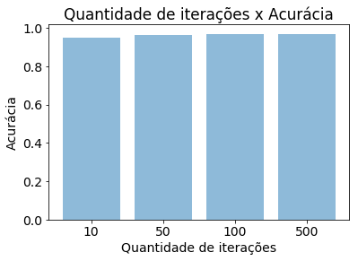

```python
#
# Mostra graficamente a variação de valores
#

showVariationsGraph(execsGTB, 'Quantidade de iterações')
```

O Gradient Tree Bosting obteve resultados interessantes. Para 100 iterações ele obteve acurácias de treino e teste bem altas, no entando quanto aumentamos as iterações para 500 ele obteve 100% de acurácia no treino, o mesmo não é percebido nos testes que são acrescidos em apenas 0.3 décimos. Ou seja, a diferença na acurácia de treino foi pequena. Como a diferença de tempo de execução entre ambos foi notória, foi assumido que o valor 100 dentre os testados obteve melhor resultado.

# Avaliação dos métodos

```python
# arrays onde serao salvos os valores de cada metodo avalidao
namesMethods = []
valuesMethods = []
matrixMethods = [['Names','Precision','Recall']]
```

```python
#
# Função de avaliação de métodos, recebe o classificador a ser avaliado e o nome do método
#

def evaluation_method(clf, nameMethod):
    # Validação cruzada utilizando k-fold
    cv = KFold(n_splits=5)

    # Define variáveis
    tprs = []
    aucs = []
    mean_fpr = np.linspace(0, 1, 100)
    i = 0
    plt.figure(figsize=(8, 8))

    # Calcula as probabilidades para cada conjunto definido pelo k-fold
    for train, test in cv.split(x, y):
        clff = clf.fit(x[train], y[train])
        y_pred = clff.predict(x[test])
        y_prob = clff.predict_proba(x[test])[:, 1]

        # Computa a curva ROC e a área de curvatura
        fpr, tpr, thresholds = roc_curve(y[test], y_prob)

        tprs.append(interp(mean_fpr, fpr, tpr))
        tprs[-1][0] = 0.0
        roc_auc = auc(fpr, tpr)
        aucs.append(roc_auc)
        plt.plot(fpr, tpr, lw=1, alpha=0.3,
                 label='ROC fold %d (AUC = %0.2f)' % (i, roc_auc))
        i += 1

    y_pred = clff.predict(x_test)
    precisionMethod = precision_score(y_test, y_pred)
    recallMethod = recall_score(y_test, y_pred)

    print("")
    print("\tPrecision: %1.3f" % precisionMethod)
    print("\tRecall: %1.3f" % recallMethod)

    namesMethods.append(nameMethod)
    valuesMethods.append([precisionMethod, recallMethod])
    matrixMethods.append([nameMethod, precisionMethod, recallMethod])

    plt.plot([0, 1], [0, 1], linestyle='--', lw=2, color='r',
             label='Chance', alpha=.8)

    mean_tpr = np.mean(tprs, axis=0)
    mean_tpr[-1] = 1.0
    mean_auc = auc(mean_fpr, mean_tpr)
    std_auc = np.std(aucs)
    plt.plot(mean_fpr, mean_tpr, color='b',
             label=r'Mean ROC (AUC = %0.2f $\pm$ %0.2f)' % (mean_auc, std_auc),
             lw=2, alpha=.8)

    std_tpr = np.std(tprs, axis=0)
    tprs_upper = np.minimum(mean_tpr + std_tpr, 1)
    tprs_lower = np.maximum(mean_tpr - std_tpr, 0)
    plt.fill_between(mean_fpr, tprs_lower, tprs_upper, color='grey', alpha=.2,
                     label=r'$\pm$ 1 std. dev.')

    plt.xlim([-0.05, 1.05])
    plt.ylim([-0.05, 1.05])
    plt.xlabel('False Positive Rate')
    plt.ylabel('True Positive Rate')
    plt.title('Curva ROC (' + nameMethod + ')')
    plt.legend(loc="lower right")
    plt.show()
```

### Naive Bayes

```
	Precision: 0.849
	Recall: 0.964
```

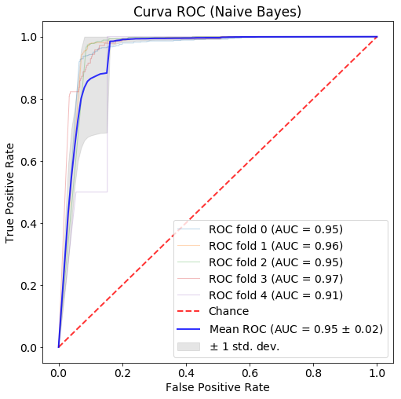

```python
#
# Define o classificador Naive Bayes
#

clf = GaussianNB()
evaluation_method(clf, 'Naive Bayes')
```

### Decision Tree

```
	Precision: 0.971
	Recall: 1.000
```

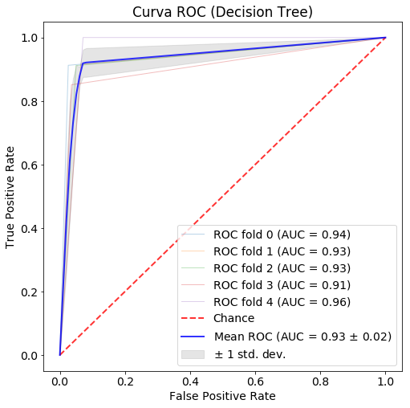

```python
#
# Define o classificador Decision Tree
#

clf = DecisionTreeClassifier(max_depth=100)
evaluation_method(clf, 'Decision Tree')
```

### Support Vector Machine

```
	Precision: 0.846
	Recall: 0.959
```

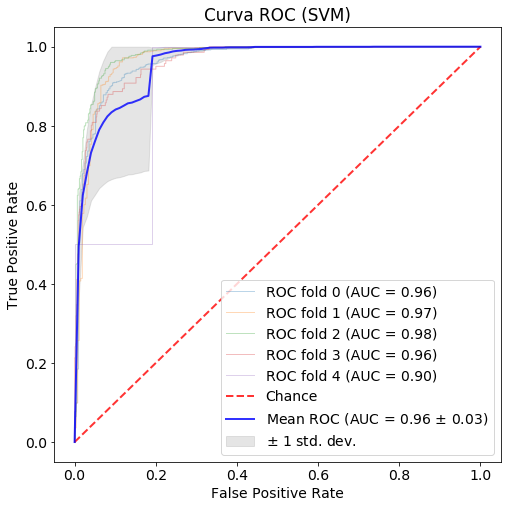

```python
#
# Define o classificador SVM
#

clf = svm.SVC(C=0.01, kernel="linear", probability=True)
evaluation_method(clf, 'SVM')
```

### k-Nearest Neighbors (KNN)

```
	Precision: 0.787
	Recall: 0.978
```

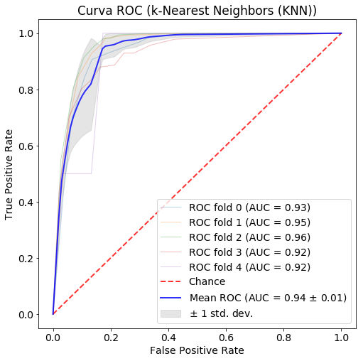

```python
#
# Define o classificador k-Nearest Neighbors (KNN)
#

clf = neighbors.KNeighborsClassifier(n_neighbors=10)
evaluation_method(clf, 'k-Nearest Neighbors (KNN)')
```

### Random Forest

```
	Precision: 0.988
	Recall: 1.000
```

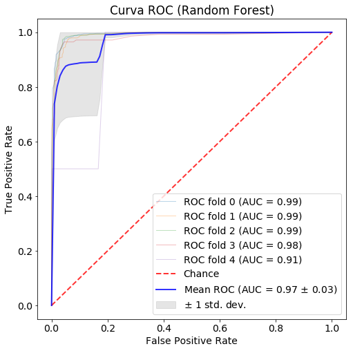

```python
#
# Define o classificador Random Forest
#

clf = ensemble.RandomForestClassifier(n_estimators=50)
evaluation_method(clf, 'Random Forest')
```

### Gradient Tree Boosting

```
	Precision: 0.972
	Recall: 0.991
```

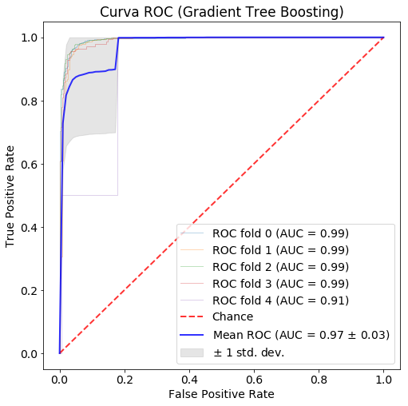

```python
#
# Define o classificador Gradient Tree Boosting
#

clf = GradientBoostingClassifier(n_estimators=100)
evaluation_method(clf, 'Gradient Tree Boosting')
```

## Comparação dos métodos

```python
pd.DataFrame(matrixMethods, columns=['Método', 'Precision', 'Recall'])
```

|  | Método | Precision | Recall |
| --- | --- | --- | --- |
| 0 | Names | Precision | Recall |
| 1 | Naive Bayes | 0.849448 | 0.96395 |
| 2 | Decision Tree | 0.971081 | 1 |
| 3 | SVM | 0.846473 | 0.959248 |
| 4 | k-Nearest Neighbors (KNN) | 0.786885 | 0.978056 |
| 5 | Random Forest | 0.987616 | 1 |
| 6 | Gradient Tree Boosting | 0.972308 | 0.990596 |

A analise ROC (Receiver Operating Characteristic) é uma ferramenta poderosa para medir e especificar problemas no desempenho de algoritmos.

Em geral todos os modelos apontaram para um alto valor de acertos (True Positives), talvez pela quantidade de dados ser pequena. Os resultados de todos os métodos testados foram considerados muito bons.

Outro ponto importante é que podemos observar uma curva similar em todos os métodos. Ou seja, pela parametrização e experimentação, foi possível obter valores altos, talvez pelo tamanho pequeno dos dados.

# Conclusão do trabalho

Neste trabalho foi realizado um experimento em aprendizado de máquina para resolução de um problema de classificação binária para candidatos a exoplanetas. O experimento inicial foi realizado com seis métodos de classificação: Naive Bayes, Decision Tree, k-Nearest Neighbors, Support Vector Machines, Random Forest e Gradient Tree Boosting. Para cada modelo foi calculada sua acurária e validação cruzada k-fold com k=5. Os valoes encontrados na acurácia e na validação cruzada em todos os seis modelos testados foram muito altos.

Em relação à realização do projeto como trabalho prático da disciplina, foi possível perceber um crescimento e aprendizado enorme em relação à: programação em Python, pois não tenho experiência na linguagem; introdução ao Jupyter Notebook, ferramenta que nunca havia trabalhado e aplicação de experiemtos de Machine Learning, algo que também não tenho muita vivência. Considerei os resultados de estudo e aprendizado muito bons, a curva de aprendizado muito pequena (em um dia consegui realizar quase 80% do trabalho, mesmo sem ter experiência com as tecnologias adquiridas), e as demandas do trabalho suficientes para uma primeira experiência de trabaho na área.